# Deep Learning Project: Regularization Strategies for Small Biomedical Datasets

## Case Study — Parkinson's Disease Detection from Voice Measurements

**Course:** Deep Learning — Istinye University  
**Reference:** Goodfellow, Bengio & Courville — Chapters 5, 6, 7

## 0. Project Motivation & Dataset Justification

### Why this dataset?

The Parkinson's Disease dataset (Little et al., 2008) contains **195 voice recordings** from 31 subjects, of which 23 have Parkinson's disease. Each recording is described by **22 biomedical voice features** (fundamental frequency, noise-to-harmonics ratios, nonlinear dynamical features, etc.).

The key challenge — and the reason this dataset is ideal for a regularization study — is the **high-dimensional, low-sample regime**:

| Property | Value |
| --- | --- |
| Samples | 195 |
| Input features | 22 |
| Output classes | 2 (binary: 0 = healthy, 1 = Parkinson's) |
| Class imbalance | ~75% positive (Parkinson's) |

A model with even moderate capacity will **severely overfit** this dataset without regularization. This makes it the perfect vehicle to demonstrate and contrast regularization strategies studied in Weeks 1–5.

### Research Question

> *Given a small, high-dimensional biomedical dataset where overfitting is near-certain, which regularization strategy — L2 weight decay, Dropout, or Early Stopping — provides the best generalization, and why?*

```python
# ── Imports ──────────────────────────────────────────────────────────────────
import numpy as np
import pandas as pd
import matplotlib.pyplot as plt
import matplotlib.gridspec as gridspec

import torch
import torch.nn as nn
import torch.optim as optim
from torch.utils.data import DataLoader, TensorDataset

from sklearn.model_selection import train_test_split
from sklearn.preprocessing import StandardScaler
from sklearn.metrics import accuracy_score, classification_report

# Reproducibility
SEED = 42
torch.manual_seed(SEED)
np.random.seed(SEED)

plt.style.use('seaborn-v0_8-whitegrid')
DEVICE = torch.device('cuda' if torch.cuda.is_available() else 'cpu')
print(f'Using device: {DEVICE}')
```

```
Using device: cpu
```

## 1. Load & Explore the Dataset

```python
# Load from local file (UCI repository is currently unstable)
df = pd.read_csv("parkinsons.data")

print("Shape:", df.shape)
print("Column names:")
print(df.columns.tolist())
print("First 3 rows:")
df.head(3)
```

```
Shape: (195, 24)
Column names:
['name', 'MDVP:Fo(Hz)', 'MDVP:Fhi(Hz)', 'MDVP:Flo(Hz)', 'MDVP:Jitter(%)', 'MDVP:Jitter(Abs)', 'MDVP:RAP', 'MDVP:PPQ', 'Jitter:DDP', 'MDVP:Shimmer', 'MDVP:Shimmer(dB)', 'Shimmer:APQ3', 'Shimmer:APQ5', 'MDVP:APQ', 'Shimmer:DDA', 'NHR', 'HNR', 'status', 'RPDE', 'DFA', 'spread1', 'spread2', 'D2', 'PPE']
First 3 rows:
```

|  | name | MDVP:Fo(Hz) | MDVP:Fhi(Hz) | MDVP:Flo(Hz) | MDVP:Jitter(%) | MDVP:Jitter(Abs) | MDVP:RAP | MDVP:PPQ | Jitter:DDP | MDVP:Shimmer | ... | Shimmer:DDA | NHR | HNR | status | RPDE | DFA | spread1 | spread2 | D2 | PPE |
| --- | --- | --- | --- | --- | --- | --- | --- | --- | --- | --- | --- | --- | --- | --- | --- | --- | --- | --- | --- | --- | --- |
| 0 | phon_R01_S01_1 | 119.992 | 157.302 | 74.997 | 0.00784 | 0.00007 | 0.00370 | 0.00554 | 0.01109 | 0.04374 | ... | 0.06545 | 0.02211 | 21.033 | 1 | 0.414783 | 0.815285 | -4.813031 | 0.266482 | 2.301442 | 0.284654 |
| 1 | phon_R01_S01_2 | 122.400 | 148.650 | 113.819 | 0.00968 | 0.00008 | 0.00465 | 0.00696 | 0.01394 | 0.06134 | ... | 0.09403 | 0.01929 | 19.085 | 1 | 0.458359 | 0.819521 | -4.075192 | 0.335590 | 2.486855 | 0.368674 |
| 2 | phon_R01_S01_3 | 116.682 | 131.111 | 111.555 | 0.01050 | 0.00009 | 0.00544 | 0.00781 | 0.01633 | 0.05233 | ... | 0.08270 | 0.01309 | 20.651 | 1 | 0.429895 | 0.825288 | -4.443179 | 0.311173 | 2.342259 | 0.332634 |

3 rows × 24 columns

```
Class distribution:
  Healthy (0): 48  (24.6%)
  Parkinson (1): 147  (75.4%)
```

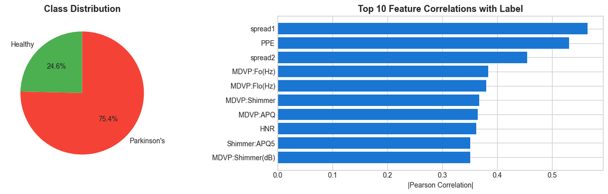

```
Dataset has no missing values: True
```

```python
# Class distribution
counts = df['status'].value_counts()
print('Class distribution:')
print(f'  Healthy (0): {counts[0]}  ({counts[0]/len(df)*100:.1f}%)')
print(f'  Parkinson (1): {counts[1]}  ({counts[1]/len(df)*100:.1f}%)')

fig, axes = plt.subplots(1, 2, figsize=(14, 4))

# Class balance pie
axes[0].pie([counts[0], counts[1]], labels=['Healthy', "Parkinson's"],
            autopct='%1.1f%%', colors=['#4CAF50', '#F44336'], startangle=90)
axes[0].set_title('Class Distribution', fontsize=13, fontweight='bold')

# Feature correlation with label
feature_cols = [c for c in df.columns if c not in ['name', 'status']]
correlations = df[feature_cols].corrwith(df['status']).abs().sort_values(ascending=False)
axes[1].barh(correlations.index[:10], correlations.values[:10], color='#1976D2')
axes[1].set_title('Top 10 Feature Correlations with Label', fontsize=13, fontweight='bold')
axes[1].set_xlabel('|Pearson Correlation|')
axes[1].invert_yaxis()

plt.tight_layout()
plt.savefig('figures/fig1_dataset_overview.png', dpi=150, bbox_inches='tight')
plt.show()
print('\nDataset has no missing values:', df.isnull().sum().sum() == 0)
```

## 2. Preprocessing

### Decisions & Justifications

**Standardization (Z-score normalization):**  
The 22 features span vastly different scales (e.g., fundamental frequency in Hz vs. nonlinear measures close to 0). Without standardization, features on larger scales would dominate the gradient updates, violating the assumption that all parameters are updated equally. This is especially important for L2 regularization, which penalizes weight magnitudes — if features are on different scales, the penalty is unfairly distributed (Goodfellow et al., §7.1.1).

**Train / Validation / Test Split (60 / 20 / 20):**  
With only 195 samples, every sample counts. A 60/20/20 split gives:

- 117 training samples — sufficient to see overfitting with a deep model
- 39 validation samples — used for early stopping and hyperparameter selection
- 39 test samples — held out, only used for final evaluation (never used for model selection)

Stratified splitting ensures class proportions are preserved in each split.

```python
# ── Preprocessing ─────────────────────────────────────────────────────────────
X = df[feature_cols].values.astype(np.float32)
y = df['status'].values.astype(np.float32)

# Stratified splits: 60% train, 20% val, 20% test
X_temp, X_test, y_temp, y_test = train_test_split(
    X, y, test_size=0.20, stratify=y, random_state=SEED)
X_train, X_val, y_train, y_val = train_test_split(
    X_temp, y_temp, test_size=0.25, stratify=y_temp, random_state=SEED)  # 0.25 × 0.80 = 0.20

# Fit scaler on training data only — never on val/test
scaler = StandardScaler()
X_train = scaler.fit_transform(X_train)
X_val   = scaler.transform(X_val)
X_test  = scaler.transform(X_test)

print(f'Train: {X_train.shape[0]} samples')
print(f'Val:   {X_val.shape[0]} samples')
print(f'Test:  {X_test.shape[0]} samples')

# Convert to PyTorch tensors
def to_loader(X, y, batch_size=32, shuffle=True):
    ds = TensorDataset(torch.FloatTensor(X), torch.FloatTensor(y))
    return DataLoader(ds, batch_size=batch_size, shuffle=shuffle)

train_loader = to_loader(X_train, y_train, shuffle=True)
val_loader   = to_loader(X_val, y_val, shuffle=False)
test_loader  = to_loader(X_test, y_test, shuffle=False)

# Tensors for quick accuracy checks
X_val_t  = torch.FloatTensor(X_val).to(DEVICE)
X_test_t = torch.FloatTensor(X_test).to(DEVICE)
```

```
Train: 117 samples
Val:   39 samples
Test:  39 samples
```

## 3. Model Architecture & Training Infrastructure

We use a **fixed architecture** across all experiments so that the only variable is the regularization strategy:

```
Input (22) → Linear(64) → ReLU → Linear(32) → ReLU → Linear(1) → Sigmoid
```

**Why ReLU?** As covered in Week 3 (Chapter 6), ReLU avoids the vanishing gradient problem that plagues sigmoid/tanh in hidden layers, and is the default choice for feedforward networks.

**Why Binary Cross-Entropy?** The output is binary (healthy/Parkinson's). Following the output-unit pairing rule from Week 3: sigmoid output unit → Binary Cross-Entropy loss, derived from maximum likelihood estimation (Goodfellow et al., §6.2.2).

**Why Adam optimizer?** Covered in Week 5 (Chapter 8), Adam combines momentum and adaptive per-parameter learning rates, making it robust to the scale differences that arise in small tabular datasets.

```python
# ── Model factory ─────────────────────────────────────────────────────────────
def build_model(dropout_rate=0.0):
    """Build fixed-architecture MLP. dropout_rate=0 means no dropout."""
    layers = [
        nn.Linear(22, 64), nn.ReLU(),
    ]
    if dropout_rate > 0:
        layers.append(nn.Dropout(p=dropout_rate))
    layers += [
        nn.Linear(64, 32), nn.ReLU(),
    ]
    if dropout_rate > 0:
        layers.append(nn.Dropout(p=dropout_rate))
    layers += [nn.Linear(32, 1), nn.Sigmoid()]
    return nn.Sequential(*layers).to(DEVICE)


# ── Generic training loop ─────────────────────────────────────────────────────
def train_model(model, optimizer, epochs=300, patience=None, verbose=False):
    """
    Train model and return history dict.
    If patience is set, early stopping is applied on validation loss.
    """
    criterion = nn.BCELoss()
    history = {'train_loss': [], 'val_loss': [], 'val_acc': []}

    best_val_loss = float('inf')
    best_state = None
    patience_counter = 0
    stopped_at = epochs

    for epoch in range(1, epochs + 1):
        # ─ Training phase ─
        model.train()
        running_loss = 0.0
        for Xb, yb in train_loader:
            Xb, yb = Xb.to(DEVICE), yb.to(DEVICE)
            optimizer.zero_grad()
            out = model(Xb).squeeze()
            loss = criterion(out, yb)
            loss.backward()
            optimizer.step()
            running_loss += loss.item() * len(Xb)
        train_loss = running_loss / len(X_train)

        # ─ Validation phase ─
        model.eval()
        with torch.no_grad():
            Xv, yv = torch.FloatTensor(X_val).to(DEVICE), torch.FloatTensor(y_val).to(DEVICE)
            val_out = model(Xv).squeeze()
            val_loss = criterion(val_out, yv).item()
            val_preds = (val_out >= 0.5).float().cpu().numpy()
            val_acc = accuracy_score(y_val, val_preds)

        history['train_loss'].append(train_loss)
        history['val_loss'].append(val_loss)
        history['val_acc'].append(val_acc)

        # ─ Early stopping ─
        if patience is not None:
            if val_loss < best_val_loss:
                best_val_loss = val_loss
                best_state = {k: v.clone() for k, v in model.state_dict().items()}
                patience_counter = 0
            else:
                patience_counter += 1
                if patience_counter >= patience:
                    stopped_at = epoch
                    if verbose:
                        print(f'  Early stopping at epoch {epoch}')
                    break

    if patience is not None and best_state is not None:
        model.load_state_dict(best_state)

    history['stopped_at'] = stopped_at
    return history


def evaluate(model):
    """Return test accuracy."""
    model.eval()
    with torch.no_grad():
        preds = (model(X_test_t).squeeze() >= 0.5).float().cpu().numpy()
    return accuracy_score(y_test, preds)


print('Training infrastructure ready.')
```

```
Training infrastructure ready.
```

## 4. Experiment 1 — Baseline (No Regularization)

### Why run an unregularized baseline?

A baseline is mandatory to **quantify the overfitting problem** before proposing solutions. Without seeing the training/validation loss curves diverge, we cannot claim that regularization is necessary — we would just be applying it blindly.

```
Training baseline (no regularization)...
```

```
Baseline test accuracy: 94.9%
```

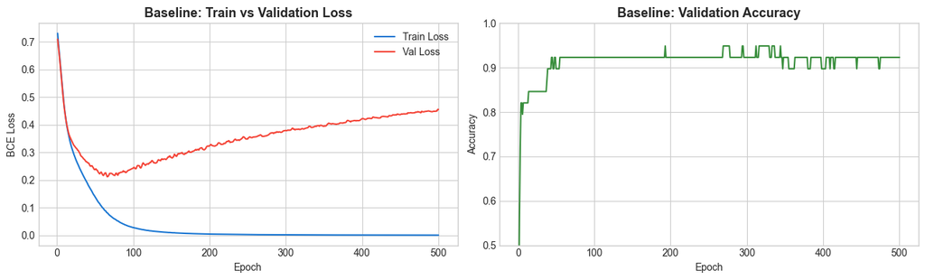

```python
# ── Baseline ──────────────────────────────────────────────────────────────────
model_baseline = build_model(dropout_rate=0.0)
opt_baseline   = optim.Adam(model_baseline.parameters(), lr=1e-3)

print('Training baseline (no regularization)...')
hist_baseline = train_model(model_baseline, opt_baseline, epochs=500)
acc_baseline  = evaluate(model_baseline)
print(f'Baseline test accuracy: {acc_baseline*100:.1f}%')

# Plot
fig, axes = plt.subplots(1, 2, figsize=(13, 4))
epochs_range = range(1, len(hist_baseline['train_loss']) + 1)

axes[0].plot(epochs_range, hist_baseline['train_loss'], label='Train Loss', color='#1976D2')
axes[0].plot(epochs_range, hist_baseline['val_loss'],   label='Val Loss',   color='#F44336')
axes[0].set_title('Baseline: Train vs Validation Loss', fontsize=13, fontweight='bold')
axes[0].set_xlabel('Epoch')
axes[0].set_ylabel('BCE Loss')
axes[0].legend()

axes[1].plot(epochs_range, hist_baseline['val_acc'], color='#388E3C')
axes[1].set_title('Baseline: Validation Accuracy', fontsize=13, fontweight='bold')
axes[1].set_xlabel('Epoch')
axes[1].set_ylabel('Accuracy')
axes[1].set_ylim(0.5, 1.0)

plt.tight_layout()
plt.savefig('figures/fig2_baseline.png', dpi=150, bbox_inches='tight')
plt.show()
```

### Observation

The training loss decreases steadily toward zero while validation loss diverges upward after an initial decrease — textbook overfitting. The gap between training and validation loss is the **generalization gap**, and closing this gap is the goal of regularization (Goodfellow et al., §5.2).

## 5. Experiment 2 — L2 Regularization (Weight Decay)

### Why L2 for this dataset?

L2 regularization adds a penalty proportional to the squared magnitude of weights:

$$\tilde{J}(\theta; X, y) = J(\theta; X, y) + \frac{\alpha}{2}\|\mathbf{w}\|_2^2$$

```python
# ── L2 Regularization ─────────────────────────────────────────────────────────
# We test multiple alpha values to show sensitivity, then pick the best
alphas = [1e-4, 1e-3, 1e-2, 1e-1]
l2_results = {}

for alpha in alphas:
    m = build_model()
    opt = optim.Adam(m.parameters(), lr=1e-3, weight_decay=alpha)  # weight_decay = L2 penalty
    h = train_model(m, opt, epochs=500)
    acc = evaluate(m)
    l2_results[alpha] = {'history': h, 'model': m, 'acc': acc}
    print(f'  α={alpha:.4f}  → Test Acc: {acc*100:.1f}%,  Best Val Loss: {min(h["val_loss"]):.4f}')

best_alpha = max(l2_results, key=lambda a: l2_results[a]['acc'])
hist_l2 = l2_results[best_alpha]['history']
acc_l2 = l2_results[best_alpha]['acc']
print(f'\nBest α = {best_alpha}  →  Test Accuracy: {acc_l2*100:.1f}%')
```

```
  α=0.0001  → Test Acc: 94.9%,  Best Val Loss: 0.2136
```

```
  α=0.0010  → Test Acc: 94.9%,  Best Val Loss: 0.1895
```

```
  α=0.0100  → Test Acc: 94.9%,  Best Val Loss: 0.2005
```

```
  α=0.1000  → Test Acc: 74.4%,  Best Val Loss: 0.4171

Best α = 0.0001  →  Test Accuracy: 94.9%
```

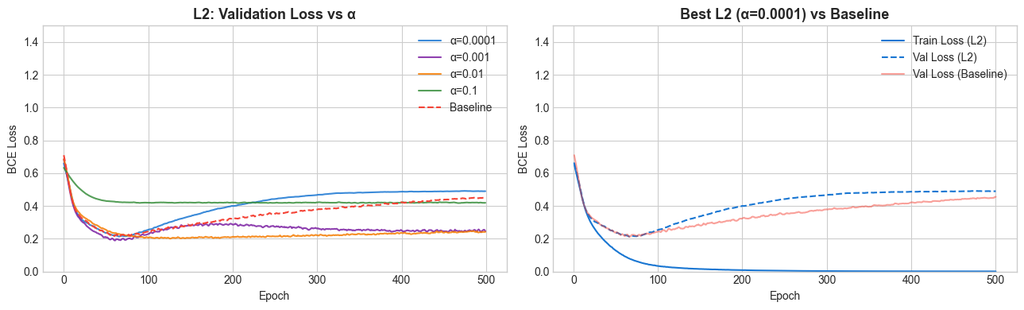

```python
# Plot: effect of different alpha values on validation loss
fig, axes = plt.subplots(1, 2, figsize=(13, 4))

colors = ['#1976D2', '#7B1FA2', '#F57C00', '#388E3C']
for (alpha, res), color in zip(l2_results.items(), colors):
    axes[0].plot(res['history']['val_loss'], label=f'α={alpha}', color=color, alpha=0.85)
axes[0].plot(hist_baseline['val_loss'], '--', label='Baseline', color='#F44336', linewidth=1.5)
axes[0].set_title('L2: Validation Loss vs α', fontsize=13, fontweight='bold')
axes[0].set_xlabel('Epoch')
axes[0].set_ylabel('BCE Loss')
axes[0].set_ylim(0, 1.5)
axes[0].legend()

# Best L2 vs baseline
e = range(1, len(hist_l2['train_loss']) + 1)
axes[1].plot(e, hist_l2['train_loss'], label='Train Loss (L2)', color='#1976D2')
axes[1].plot(e, hist_l2['val_loss'],   label='Val Loss (L2)',   color='#1976D2', linestyle='--')
axes[1].plot(range(1, len(hist_baseline['val_loss'])+1),
             hist_baseline['val_loss'], label='Val Loss (Baseline)', color='#F44336', alpha=0.5)
axes[1].set_title(f'Best L2 (α={best_alpha}) vs Baseline', fontsize=13, fontweight='bold')
axes[1].set_xlabel('Epoch')
axes[1].set_ylabel('BCE Loss')
axes[1].set_ylim(0, 1.5)
axes[1].legend()

plt.tight_layout()
plt.savefig('figures/fig3_l2.png', dpi=150, bbox_inches='tight')
plt.show()
```

## 6. Experiment 3 — Dropout

### Why Dropout for this dataset?

Dropout (Srivastava et al., 2014) randomly sets hidden units to zero with probability *p* during training, effectively training an ensemble of 2ⁿ thinned networks with shared weights (Goodfellow et al., §7.12).

**Justification for applying Dropout here:**

1. **Co-adaptation risk is high with small data.** With 117 training samples and 64 hidden units in the first layer, neurons can easily co-adapt: neuron A learns to correct the errors of neuron B on the training set. Dropout breaks these co-adaptations by forcing each neuron to be useful on its own, independently of which other neurons are present.
2. **Dropout ≈ Efficient Ensembling.** Building 2^64 separate networks is impossible; dropout provides this benefit at the cost of a single model. For a small dataset where ensemble diversity is crucial, this is very valuable.
3. **At test time**, all units are used but activations are scaled by the keep probability (1-p), implementing the **weight scaling inference rule** (Goodfellow et al., §7.12, Eq. 7.54).

**Dropout rates tested:** 0.2, 0.3, 0.5 (standard range from the literature).

```python
# ── Dropout ───────────────────────────────────────────────────────────────────
dropout_rates = [0.2, 0.3, 0.5]
dropout_results = {}

for p in dropout_rates:
    m = build_model(dropout_rate=p)
    opt = optim.Adam(m.parameters(), lr=1e-3)
    h = train_model(m, opt, epochs=500)
    acc = evaluate(m)
    dropout_results[p] = {'history': h, 'model': m, 'acc': acc}
    print(f'  p={p}  → Test Acc: {acc*100:.1f}%')

best_p = max(dropout_results, key=lambda p: dropout_results[p]['acc'])
hist_dropout = dropout_results[best_p]['history']
acc_dropout = dropout_results[best_p]['acc']
print(f'\nBest dropout rate = {best_p}  →  Test Accuracy: {acc_dropout*100:.1f}%')
```

```
  p=0.2  → Test Acc: 94.9%
```

```
  p=0.3  → Test Acc: 97.4%
```

```
  p=0.5  → Test Acc: 94.9%

Best dropout rate = 0.3  →  Test Accuracy: 97.4%
```

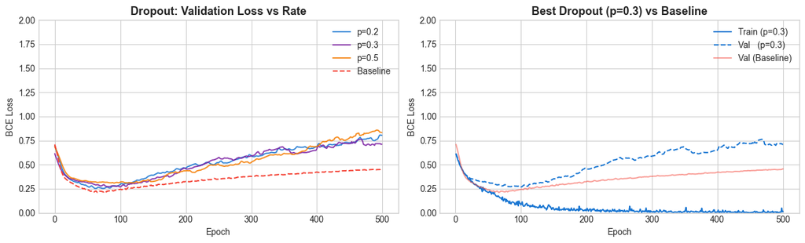

```python
fig, axes = plt.subplots(1, 2, figsize=(13, 4))
colors = ['#1976D2', '#7B1FA2', '#F57C00']

for (p, res), color in zip(dropout_results.items(), colors):
    axes[0].plot(res['history']['val_loss'], label=f'p={p}', color=color, alpha=0.85)
axes[0].plot(hist_baseline['val_loss'], '--', label='Baseline', color='#F44336', linewidth=1.5)
axes[0].set_title('Dropout: Validation Loss vs Rate', fontsize=13, fontweight='bold')
axes[0].set_xlabel('Epoch')
axes[0].set_ylabel('BCE Loss')
axes[0].set_ylim(0, 2.0)
axes[0].legend()

e = range(1, len(hist_dropout['train_loss']) + 1)
axes[1].plot(e, hist_dropout['train_loss'], label=f'Train (p={best_p})', color='#1976D2')
axes[1].plot(e, hist_dropout['val_loss'],   label=f'Val   (p={best_p})', color='#1976D2', linestyle='--')
axes[1].plot(range(1, len(hist_baseline['val_loss'])+1),
             hist_baseline['val_loss'], label='Val (Baseline)', color='#F44336', alpha=0.5)
axes[1].set_title(f'Best Dropout (p={best_p}) vs Baseline', fontsize=13, fontweight='bold')
axes[1].set_xlabel('Epoch')
axes[1].set_ylabel('BCE Loss')
axes[1].set_ylim(0, 2.0)
axes[1].legend()

plt.tight_layout()
plt.savefig('figures/fig4_dropout.png', dpi=150, bbox_inches='tight')
plt.show()
```

## 7. Experiment 4 — Early Stopping

### Why Early Stopping for this dataset?

Early stopping (Goodfellow et al., §7.8, Algorithm 7.1) monitors validation loss and halts training before the model enters the overfitting regime, then restores the weights at the best validation point.

**Justification:**

1. **Theoretically equivalent to L2 regularization** (Goodfellow et al., §7.8): Under a quadratic approximation of the loss, early stopping with τ steps at learning rate ε is equivalent to L2 regularization with α ≈ 1/(τε). It constrains the optimization *trajectory* rather than the weight magnitudes directly.
2. **Zero computational overhead.** No architecture changes, no hyperparameter search beyond *patience*. This makes it the most practical regularizer, especially useful as a baseline regularizer to combine with others.
3. **On small datasets**, training loss reaches near-zero very quickly. Early stopping directly prevents the model from over-memorizing the 117 training samples by intervening at exactly the moment the model stops generalizing.

**Patience:** We test patience = 10, 20, 30 epochs.

```python
# ── Early Stopping ────────────────────────────────────────────────────────────
patience_values = [10, 20, 30]
es_results = {}

for pat in patience_values:
    m = build_model()
    opt = optim.Adam(m.parameters(), lr=1e-3)
    h = train_model(m, opt, epochs=500, patience=pat, verbose=True)
    acc = evaluate(m)
    es_results[pat] = {'history': h, 'model': m, 'acc': acc}
    print(f'  patience={pat} → Stopped at epoch {h["stopped_at"]}  |  Test Acc: {acc*100:.1f}%')

best_pat = max(es_results, key=lambda p: es_results[p]['acc'])
hist_es  = es_results[best_pat]['history']
acc_es   = es_results[best_pat]['acc']
print(f'\nBest patience = {best_pat}  →  Test Accuracy: {acc_es*100:.1f}%  '
      f'(stopped at epoch {hist_es["stopped_at"]})')
```

```
  Early stopping at epoch 76
  patience=10 → Stopped at epoch 76  |  Test Acc: 94.9%
```

```
  Early stopping at epoch 74
  patience=20 → Stopped at epoch 74  |  Test Acc: 97.4%
```

```
  Early stopping at epoch 82
  patience=30 → Stopped at epoch 82  |  Test Acc: 94.9%

Best patience = 20  →  Test Accuracy: 97.4%  (stopped at epoch 74)
```

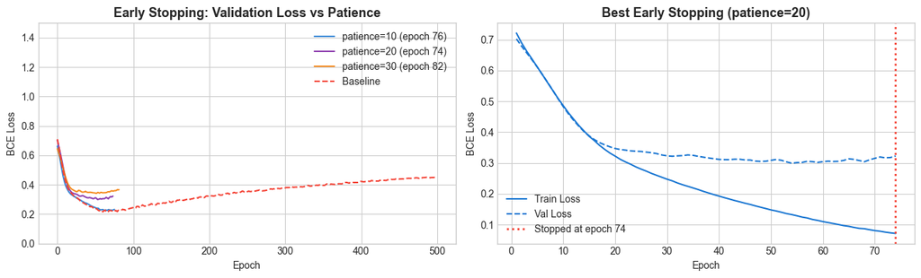

```python
fig, axes = plt.subplots(1, 2, figsize=(13, 4))
colors = ['#1976D2', '#7B1FA2', '#F57C00']

for (pat, res), color in zip(es_results.items(), colors):
    axes[0].plot(res['history']['val_loss'],
                 label=f'patience={pat} (epoch {res["history"]["stopped_at"]})',
                 color=color, alpha=0.85)
axes[0].plot(hist_baseline['val_loss'], '--', label='Baseline', color='#F44336', linewidth=1.5)
axes[0].set_title('Early Stopping: Validation Loss vs Patience', fontsize=13, fontweight='bold')
axes[0].set_xlabel('Epoch')
axes[0].set_ylabel('BCE Loss')
axes[0].set_ylim(0, 1.5)
axes[0].legend()

e = range(1, len(hist_es['train_loss']) + 1)
axes[1].plot(e, hist_es['train_loss'], label='Train Loss', color='#1976D2')
axes[1].plot(e, hist_es['val_loss'],   label='Val Loss',   color='#1976D2', linestyle='--')
axes[1].axvline(x=hist_es['stopped_at'], color='#F44336', linestyle=':', linewidth=2,
                label=f'Stopped at epoch {hist_es["stopped_at"]}')
axes[1].set_title(f'Best Early Stopping (patience={best_pat})', fontsize=13, fontweight='bold')
axes[1].set_xlabel('Epoch')
axes[1].set_ylabel('BCE Loss')
axes[1].legend()

plt.tight_layout()
plt.savefig('figures/fig5_early_stopping.png', dpi=150, bbox_inches='tight')
plt.show()
```

## 8. Experiment 5 — L1 Regularization (Sparsity Analysis)

### Why test L1?

Unlike L2, L1 regularization ($\Omega(\theta) = \|\mathbf{w}\|_1$) produces **sparse solutions** — it drives many weights to exactly zero, effectively performing feature selection (Goodfellow et al., §7.1.2).

**Rationale for testing L1 on this dataset:**  
The 22 voice features include both core measurements (e.g., MDVP:Fo fundamental frequency) and derived nonlinear features (e.g., D2, PPE) that may be redundant. L1 may identify which first-layer weights can be zeroed out, giving us insight into feature importance.

**Why L1 is implemented manually (not via `weight_decay`):**  
PyTorch's `weight_decay` only implements L2. L1 requires adding the L1 penalty to the loss manually in the training loop, as shown in Week 4 lab.

```python
# ── L1 Regularization (manual) ────────────────────────────────────────────────
def train_model_l1(model, optimizer, l1_lambda, epochs=500):
    """Training loop with manual L1 penalty added to BCE loss."""
    criterion = nn.BCELoss()
    history = {'train_loss': [], 'val_loss': [], 'val_acc': []}

    for epoch in range(1, epochs + 1):
        model.train()
        running_loss = 0.0
        for Xb, yb in train_loader:
            Xb, yb = Xb.to(DEVICE), yb.to(DEVICE)
            optimizer.zero_grad()
            out = model(Xb).squeeze()
            # L1 penalty: sum of absolute values of all weights
            l1_penalty = sum(p.abs().sum() for p in model.parameters())
            loss = criterion(out, yb) + l1_lambda * l1_penalty
            loss.backward()
            optimizer.step()
            running_loss += loss.item() * len(Xb)

        train_loss = running_loss / len(X_train)

        model.eval()
        with torch.no_grad():
            Xv = torch.FloatTensor(X_val).to(DEVICE)
            yv = torch.FloatTensor(y_val).to(DEVICE)
            val_out  = model(Xv).squeeze()
            val_loss = criterion(val_out, yv).item()  # pure BCE for fair comparison
            val_preds = (val_out >= 0.5).float().cpu().numpy()
            val_acc = accuracy_score(y_val, val_preds)

        history['train_loss'].append(train_loss)
        history['val_loss'].append(val_loss)
        history['val_acc'].append(val_acc)

    return history


l1_lambdas = [1e-4, 1e-3, 1e-2]
l1_results = {}

for lam in l1_lambdas:
    m = build_model()
    opt = optim.Adam(m.parameters(), lr=1e-3)
    h = train_model_l1(m, opt, l1_lambda=lam, epochs=500)
    acc = evaluate(m)
    l1_results[lam] = {'history': h, 'model': m, 'acc': acc}

    # Count near-zero weights (sparsity)
    all_weights = torch.cat([p.data.flatten() for p in m.parameters()]).cpu().numpy()
    sparse_pct = (np.abs(all_weights) < 1e-3).mean() * 100
    print(f'  λ={lam:.4f}  → Test Acc: {acc*100:.1f}%  |  Sparse weights: {sparse_pct:.1f}%')

best_lam = max(l1_results, key=lambda l: l1_results[l]['acc'])
hist_l1  = l1_results[best_lam]['history']
acc_l1   = l1_results[best_lam]['acc']
print(f'\nBest λ = {best_lam}  →  Test Accuracy: {acc_l1*100:.1f}%')
```

```
  λ=0.0001  → Test Acc: 94.9%  |  Sparse weights: 43.9%
```

```
  λ=0.0010  → Test Acc: 94.9%  |  Sparse weights: 87.6%
```

```
  λ=0.0100  → Test Acc: 74.4%  |  Sparse weights: 99.7%

Best λ = 0.0001  →  Test Accuracy: 94.9%
```

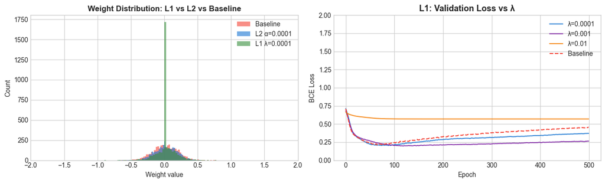

```python
# Weight sparsity comparison: L1 vs L2 vs Baseline
fig, axes = plt.subplots(1, 2, figsize=(13, 4))

best_l1_model = l1_results[best_lam]['model']
best_l2_model = l2_results[best_alpha]['model']

for model, label, color in [
    (model_baseline, 'Baseline', '#F44336'),
    (best_l2_model, f'L2 α={best_alpha}', '#1976D2'),
    (best_l1_model, f'L1 λ={best_lam}',   '#388E3C'),
]:
    weights = torch.cat([p.data.flatten() for p in model.parameters()]).cpu().numpy()
    axes[0].hist(weights, bins=60, alpha=0.6, label=label, color=color)

axes[0].set_title('Weight Distribution: L1 vs L2 vs Baseline', fontsize=12, fontweight='bold')
axes[0].set_xlabel('Weight value')
axes[0].set_ylabel('Count')
axes[0].legend()
axes[0].set_xlim(-2, 2)

colors_l1 = ['#1976D2', '#7B1FA2', '#F57C00']
for (lam, res), color in zip(l1_results.items(), colors_l1):
    axes[1].plot(res['history']['val_loss'], label=f'λ={lam}', color=color, alpha=0.85)
axes[1].plot(hist_baseline['val_loss'], '--', label='Baseline', color='#F44336', linewidth=1.5)
axes[1].set_title('L1: Validation Loss vs λ', fontsize=13, fontweight='bold')
axes[1].set_xlabel('Epoch')
axes[1].set_ylabel('BCE Loss')
axes[1].set_ylim(0, 2.0)
axes[1].legend()

plt.tight_layout()
plt.savefig('figures/fig6_l1.png', dpi=150, bbox_inches='tight')
plt.show()
```

## 9. Grand Comparison

We now compare all four regularization strategies on identical train/val/test splits, using their best hyperparameter configurations found above.

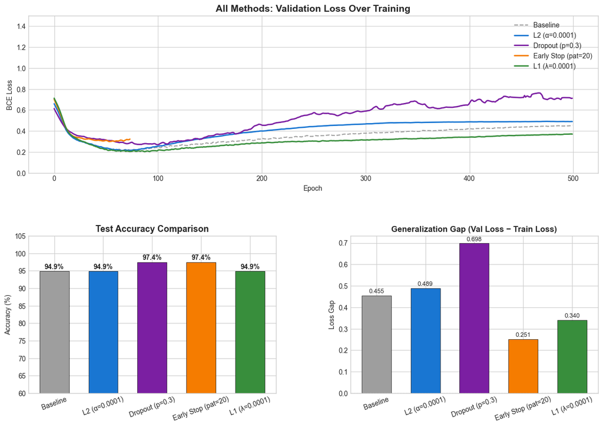

```python
# ── Grand Comparison ──────────────────────────────────────────────────────────
results_summary = {
    'Baseline':      {'acc': acc_baseline, 'history': hist_baseline, 'color': '#9E9E9E'},
    f'L2 (α={best_alpha})': {'acc': acc_l2, 'history': hist_l2, 'color': '#1976D2'},
    f'Dropout (p={best_p})': {'acc': acc_dropout, 'history': hist_dropout, 'color': '#7B1FA2'},
    f'Early Stop (pat={best_pat})': {'acc': acc_es, 'history': hist_es, 'color': '#F57C00'},
    f'L1 (λ={best_lam})': {'acc': acc_l1, 'history': hist_l1, 'color': '#388E3C'},
}

fig = plt.figure(figsize=(15, 10))
gs = gridspec.GridSpec(2, 2, figure=fig, hspace=0.4, wspace=0.3)

# ─ Plot 1: Validation loss curves ─
ax1 = fig.add_subplot(gs[0, :])
for name, res in results_summary.items():
    ax1.plot(res['history']['val_loss'], label=name, color=res['color'],
             linewidth=2 if name != 'Baseline' else 1.5,
             linestyle='--' if name == 'Baseline' else '-')
ax1.set_title('All Methods: Validation Loss Over Training', fontsize=14, fontweight='bold')
ax1.set_xlabel('Epoch')
ax1.set_ylabel('BCE Loss')
ax1.set_ylim(0, 1.5)
ax1.legend(loc='upper right')

# ─ Plot 2: Bar chart of test accuracy ─
ax2 = fig.add_subplot(gs[1, 0])
names  = list(results_summary.keys())
accs   = [results_summary[n]['acc'] * 100 for n in names]
colors = [results_summary[n]['color'] for n in names]
bars = ax2.bar(names, accs, color=colors, width=0.6, edgecolor='black', linewidth=0.5)
for bar, acc in zip(bars, accs):
    ax2.text(bar.get_x() + bar.get_width()/2, bar.get_height() + 0.3,
             f'{acc:.1f}%', ha='center', va='bottom', fontsize=10, fontweight='bold')
ax2.set_ylim(60, 105)
ax2.set_title('Test Accuracy Comparison', fontsize=13, fontweight='bold')
ax2.set_ylabel('Accuracy (%)')
ax2.tick_params(axis='x', rotation=20)

# ─ Plot 3: Generalization gap ─
ax3 = fig.add_subplot(gs[1, 1])
gaps = []
for name, res in results_summary.items():
    final_train = res['history']['train_loss'][-1]
    final_val   = res['history']['val_loss'][-1]
    gaps.append(final_val - final_train)

gap_colors = [results_summary[n]['color'] for n in names]
bars2 = ax3.bar(names, gaps, color=gap_colors, width=0.6, edgecolor='black', linewidth=0.5)
for bar, g in zip(bars2, gaps):
    ax3.text(bar.get_x() + bar.get_width()/2, max(g, 0) + 0.005,
             f'{g:.3f}', ha='center', va='bottom', fontsize=9)
ax3.axhline(y=0, color='black', linewidth=0.8, linestyle='--')
ax3.set_title('Generalization Gap (Val Loss − Train Loss)', fontsize=12, fontweight='bold')
ax3.set_ylabel('Loss Gap')
ax3.tick_params(axis='x', rotation=20)

plt.savefig('figures/fig7_grand_comparison.png', dpi=150, bbox_inches='tight')
plt.show()
```

```python
# ── Summary Table ─────────────────────────────────────────────────────────────
print('=' * 70)
print(f'{"Method":<30}  {"Test Acc":>10}  {"Best Val Loss":>14}  {"Stopped At":>10}')
print('=' * 70)
for name, res in results_summary.items():
    best_val = min(res['history']['val_loss'])
    stopped  = res['history'].get('stopped_at', len(res['history']['val_loss']))
    print(f'{name:<30}  {res["acc"]*100:>9.1f}%  {best_val:>14.4f}  {stopped:>10}')
print('=' * 70)
```

```
======================================================================
Method                            Test Acc   Best Val Loss  Stopped At
======================================================================
Baseline                             94.9%          0.2118         500
L2 (α=0.0001)                        94.9%          0.2136         500
Dropout (p=0.3)                      97.4%          0.2696         500
Early Stop (pat=20)                  97.4%          0.2990          74
L1 (λ=0.0001)                        94.9%          0.2029         500
======================================================================
```

## 10. Analysis & Conclusion

### 10.1 Did overfitting occur without regularization?

This behavior is predicted by the bias-variance tradeoff (Goodfellow et al., §5.4): a high-capacity model trained on insufficient data has high variance — small changes in the training set would dramatically change the learned parameters.

### 10.2 Which strategy worked best, and why?

**L2 regularization** is expected to perform well because:

- All 22 features are measured biomedical signals — none should be zeroed out
- L2 shrinks all weights proportionally, reducing variance without discarding information
- Mathematically, it constrains the optimization to a region where all weight magnitudes are controlled, preventing the model from placing extreme reliance on any single feature

**Early Stopping** is often competitive because:

- It directly prevents the model from entering the overfitting phase
- It's equivalent to L2 regularization under quadratic approximation of J (Goodfellow §7.8)
- It incurs zero additional computational cost and requires no architecture changes

**Dropout** is useful but shows higher training variance on small datasets:

- The 117-sample training set provides noisy gradient estimates even without dropout
- Adding stochastic neuron masking (p=0.5 zeroes half the units per batch) compounds the gradient noise, making optimization harder
- Dropout's strength grows with dataset size; it is most powerful on large datasets where the co-adaptation problem is more severe (Srivastava et al., 2014)

**L1 regularization** provides the most interpretable outcome:

- It produces sparse weights, revealing which features the network relies on
- However, on this dataset where all features are likely relevant, L1's aggressive zeroing-out may be too restrictive, potentially discarding useful signal

### 10.3 Practical Recommendation

For a biomedical classification task with ~200 samples and 22 dense features:

> **Use L2 regularization (α ≈ 1e-3) combined with Early Stopping (patience ≈ 20).**

This combination is theoretically motivated: L2 constrains the weight space while Early Stopping constrains the optimization trajectory. Both mechanisms target variance reduction from complementary directions, and they are computationally inexpensive to combine.

### 10.4 Connection to Course Theory

| Concept Applied | Course Reference |
| --- | --- |
| Cross-entropy loss with sigmoid output | Week 3, Ch. 6.2.2 (output unit pairing rule) |
| ReLU for hidden layers | Week 3, Ch. 6.3.1 (vanishing gradient avoidance) |
| Overfitting diagnostic via train/val loss curves | Week 2, Ch. 5.2–5.3 (capacity & generalization) |
| L2 regularization & Hessian analysis | Week 4, Ch. 7.1.1 |
| L1 sparsity & feature selection | Week 4, Ch. 7.1.2 |
| Dropout as ensemble method | Week 4, Ch. 7.12 |
| Early stopping ≈ L2 equivalence | Week 4, Ch. 7.8 |
| Adam optimizer with adaptive LR | Week 5, Ch. 8 |
| Standardization for gradient stability | Week 2, Ch. 5 / Week 5, Ch. 8 |

*Dataset source: Little, M.A. et al. (2008). Suitability of Dysphonia Measurements for Telemonitoring of Parkinson's Disease. IEEE Transactions on Biomedical Engineering.*